# **FIND PATTERNS**

Usually it is a good idea to investigate relations using visualization since we are naturally prone to detect trends, relationships, etc in a visual way

When we talk about patterns in data we usually refer to relationships between two or more variables. Options to visualize two dimnensions are:

- draw multiple boxplot in one window
- scatterplot
- etc.

To add a 3rd dimension one option is to use different colors, shapes, sizes, etc.

Say we want to see if age distribution change according to car category

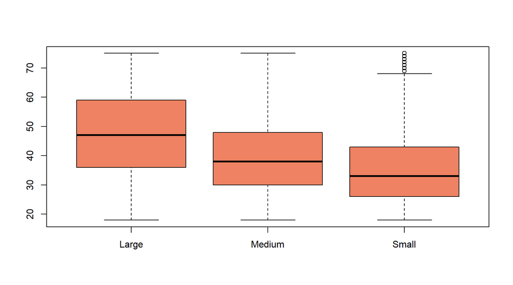

```r
# boxplot function supports formula (~) statements
boxplot(dt$Age ~ dt$Category_Car, col="salmon2")
```

The *hist()* function does not support the formula statment, but you can modify directly the global graphical parameteres in order to split the graphical device into multiple slots. Before changing global parameters it is a good idea to save a copy of original settings in order to easily go back to defaults.

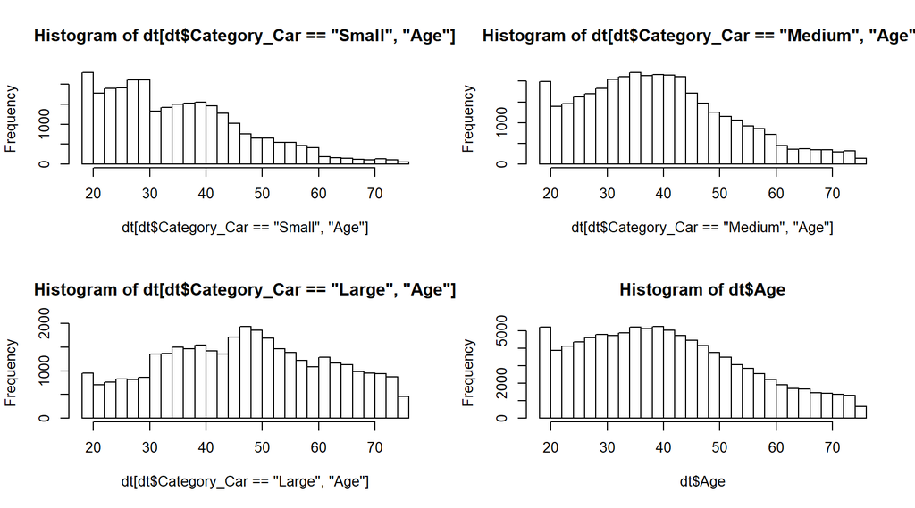

```r
parOriginal <- par(no.readonly = TRUE) # save a copy of original graphical parameters
par(mfrow=c(2,2)) # par can be used to set or query graphical parameters
hist(dt[dt$Category_Car=="Small","Age"], nclass = 30)
hist(dt[dt$Category_Car=="Medium","Age"], nclass = 30)
hist(dt[dt$Category_Car=="Large","Age"], nclass = 30)
hist(dt$Age, nclass = 30) # full age distribution
```

```r
par(parOriginal) # set default graphical parameters
```

## **SCATTERPLOT**

let’s simulate some numbers

```r
# two normal populations, with mean 2 and 4 respectively
x_a <- rnorm(50, 2)
x_b <- rnorm(50, 4)
x <- c(x_a, x_b)

# another two normal populations respectively correlated with previous ones
y_a <- x_a + rnorm(50, 0.2, 0.5)
y_b <- x_b + rnorm(50, 0.2, 1)
y <- c(y_a, y_b)

# a variable to label the two populations
l <- c(rep("A", 50), rep("B", 50))

# a dataframe including x, y and l
df <- data.frame(x=x, y=y, l=l)
```

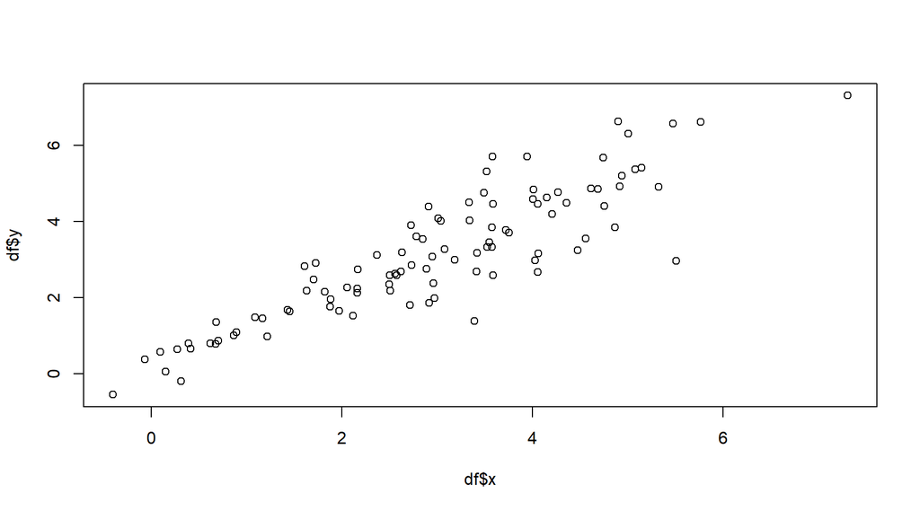

```r
# scatterplot 2-d
plot(df$x, df$y)
```

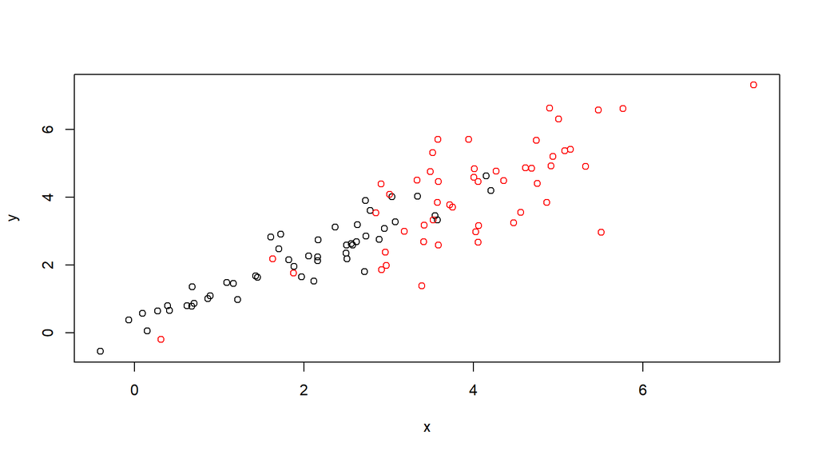

```r
# add a third dimension with colour
with(df, plot(x, y, col = l))
```

## **SPATIAL ANALYSIS**

If you are interested in the visualization of geographical attribute then a map may be a good idea. R can be used as a fast, user-friendly and extremely powerful command-line Geographic Information System (GIS)

In R there is a huge a growing number of spatial data packages. Here we will focus on *rworldmap*, a package for visualising global data, concentrating on data referenced by country.

The package stores multiple maps which can be accessed through *getMap* function

```r
newmap <- getMap(resolution = "coarse")
class(newmap)
```

```
## [1] "SpatialPolygonsDataFrame"
## attr(,"package")
## [1] "sp"
```

Maps in R are classified as spatial (sp) objects. Spatial objects are made up of a number of different slots (that can be accessed through the @ operator):

- bbox (bounding box, mostly used for setting up plots)
- data (data indeed)
- polygons/lines/points/… (the geometry instructing R how to plot maps)
- proj4string (definition of coordinate reference system)

Inside each slot you may have multiple components which, as usual, can be accessed with $ operator

For each country in the Group you have some profitability indicators. The package *rworldmap* provides a function to join country-level attributes to an internal map. All you need to do is provide the name of the column containing the country name (nameJoinColumn = ‘name’) and specify you want to join by name (joinCode = ‘NAME’)

```r
new2 <- joinCountryData2Map(new, joinCode = "NAME", nameJoinColumn = "name")
```

```
## 6 codes from your data successfully matched countries in the map
## 3 codes from your data failed to match with a country code in the map
## 237 codes from the map weren't represented in your data
```

Function *mapCountryData* in rworldmap draw a map of country-level data, allowing countries to be coloured

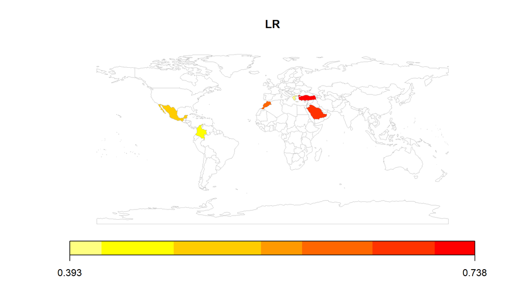

```r
mapCountryData(new2, nameColumnToPlot="LR") # Loss Ratio
```

Using spatial data in R can be challenging because there are many types and formats and there are a ton of packages from a very diverse user community. Anyway there is an increasing trend of harmonization and the capabilities offered are extremely vast. A good start is the [CRAN tutorial](https://cran.r-project.org/doc/contrib/intro-spatial-rl.pdf), or one of the many [tutorial in github](https://pakillo.github.io/R-GIS-tutorial).

# **COMMUNICATE RESULTS**

Normally after analysis results are shared with an audience and here visualization are particularly important. In general using visual aids is a good idea to conceive complex messages. When it’s time to communicate the results it is also important to adjust the visualization to make it as much as possible clear and easy to understand for the audience. In this context the sizes, shapes, widths, labels, margins, fonts, etc. are all things that become important.

## **ADDITIONAL GRAPHICAL PARAMETERS**

When applicable plot function allows you to specify many additional graphical parameters. To have a list of them type ?par

Let’s take the histogram created before and clean it a bit with additional graphical parameters

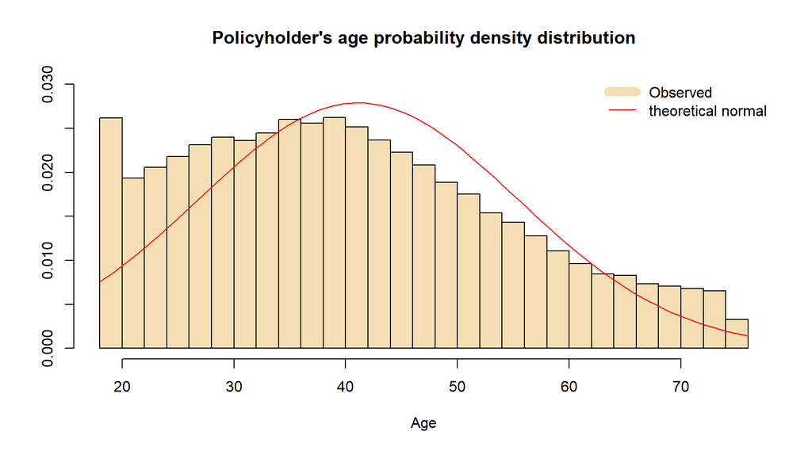

```r
hist(dt$Age,
     nclass = 30, # number of bins
     probability = TRUE,
     col="wheat", # color of bars
     border = "black", # color of border of bars
     xlab = "Age", # label of x axis
     ylab = "", # label of y axis
     ylim = c(0, 0.03),
     main = "Policyholder's age probability density distribution" # title
     )

fit <- fitdistr(dt$Age, "normal") # Maximum-likelihood fitting of univariate distributions
curve(dnorm(x, mean = fit$estimate["mean"], sd = fit$estimate["sd"]), add=T, col = "red") # Draws a curve corresponding to a function


# Also legends can be added

legend("topright", # position of legend box
       bty = "n", # box type = none
       legend = c("Observed", "theoretical normal"), # text to be displayed
       col = c("wheat", "red"), # colors
       lty = c(1,1), # line type
       lwd = c(10, 1) # line width
       )
```

## **GGPLOT**

All functions used until now belong to the *base* plotting systems. In R there are available 3 different plotting systems:

- base
- lattice
- ggplot

ggplot is an implementation of [Grammar of Graphics by Leland Wilkinson](http://www.springer.com/gp/book/9780387245447) (a set of principles for graphics). Grammar of graphics is a description of how graphics can be broken down into abstract concepts (like languages are divided in nouns, adjectives, etc.). ggplot graphics abstraction is a very powerful concept to organize all kind of graphics and became extremely popular in recent years.

ggplot2, as lattice, is built upon the grid package which is a low-level graphic system that provides full access to the graphics facilities in R. In theory the knowledge of this system will allow you to make arbitrary modifications to plots and it will allow you to produce a range of diagrams and data visualizations that is limited only by your imagination. Given the control that ggplot gives you over the graphic it is particularly suited to produce high-quality, ready-to-publish visualizations.

Briefly, the grammar tells us that a statistical graphics is a mapping from data to aesthetic attributes (colour, shape, size) of geometric objects (points, lines, bars). The plot may also contain statistical transformations of the data and is drawn on a specific coordinate system. Graphics are built with layers.

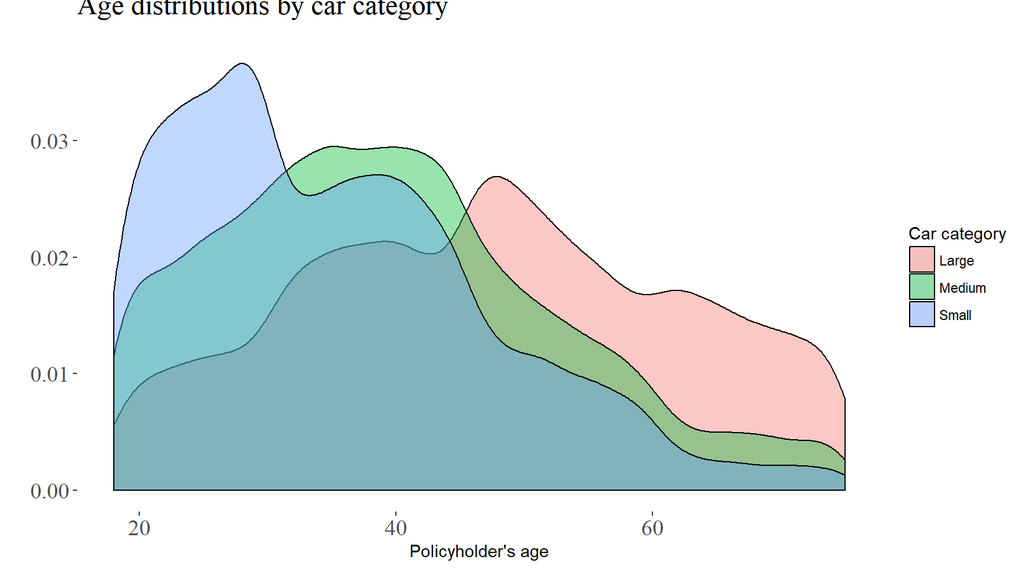

```r
# if you are using a Windows machine you need to translate some font for ggplot
windowsFonts(Times=windowsFont("TT Times New Roman"))

gg1 <-ggplot(dt, aes(x = Age, group = Category_Car, fill = Category_Car)) + # set Age on x-axis, group and fill (with color) according to the values of category_car
  geom_density(alpha = .4) + # transform age data into a density distribution summary
  xlab("Policyholder's age") + # set x-axis label
  ylab("") + # set y-axis label
  ggtitle("Age distributions by car category") + # set plot title
  guides(fill=guide_legend("Car category")) + # color legend according to values of category car
  theme(plot.title = element_text(hjust = 0, vjust=5, size = 18, family = "Times"), # set position, size and font for title
        axis.text.x = element_text(size = 14, family = "Times"), # set size and font for x axis label
        axis.text.y = element_text(size = 14, family = "Times"), # set size and font for y axis label
        panel.background = element_rect(fill = "white") # set background color
        )

gg1 # to plot ggplot plots you have to call them
```

## **COLOURS**

A careful choice of colors can help to draw better visualizations. R has 657 built in color names. Use colors() for a list of all colors known by R.

When we need to show a range of colors we can use palettes. In the map created before the palette was not specified so default of function *mapCountryData* was used (in that case a heat palette, with colors ranging gradually from yellow to red). We can customize palettes to our needs.

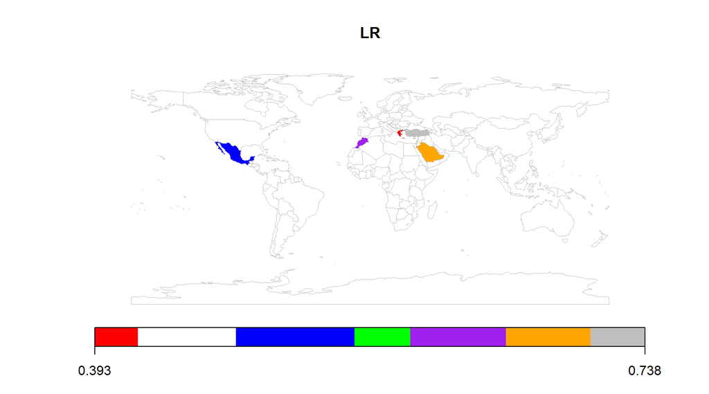

```r
# using a vector of valid colors
mapCountryData(new2, nameColumnToPlot="LR",
               colourPalette = c("red","white","blue", "green", "purple", "orange", "grey")) # not so nice, right?
```

A good package for color palettes is *RColorBrewer*. the function to create palettes is *brewer.pal*. It takes two arguments:

- n –> Number of different colors in the palette, minimum 3, maximum depending on palette
- name –> a palette name

To have a look at all available palettes you can use:

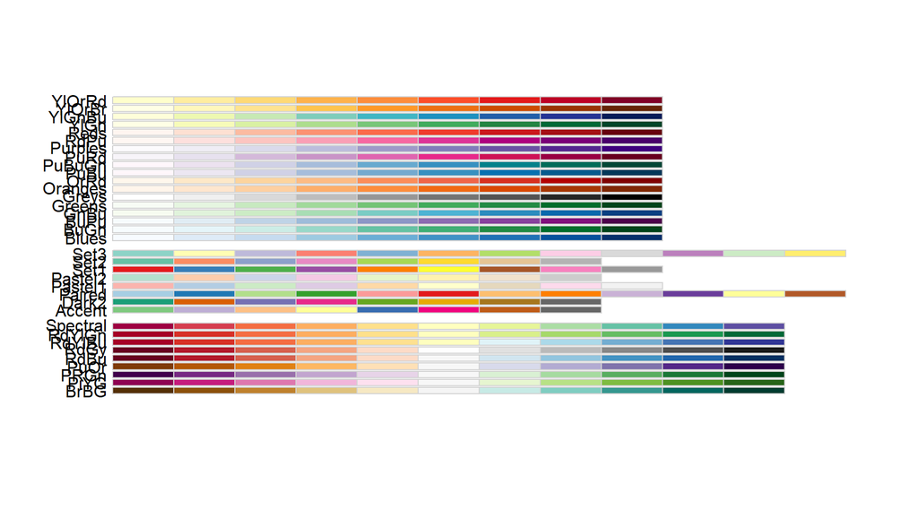

```r
display.brewer.all(n=NULL, type="all") # diverging, sequential, qualitative
```

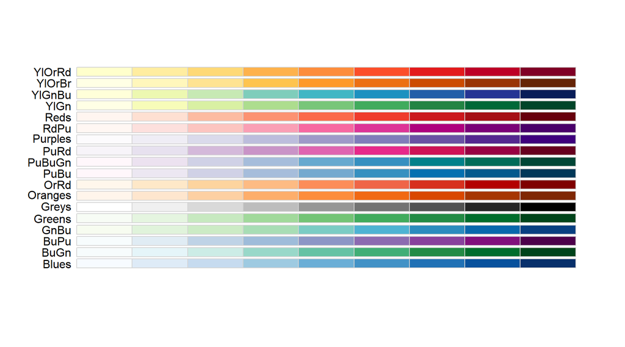

```r
display.brewer.all(n=NULL, type="seq") # only sequential
```

For an interactive viewer of palettes you can visit this [page](http://colorbrewer2.org/)

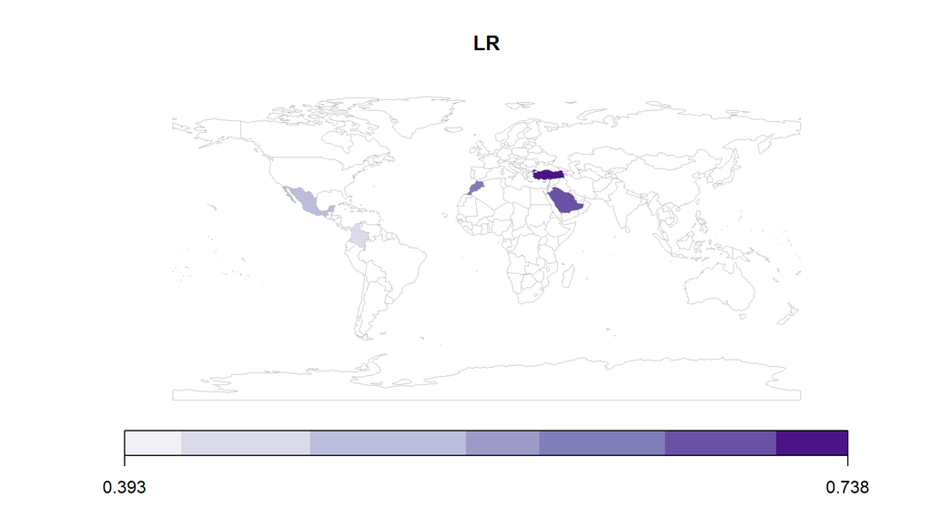

```r
# using output from RColorBrewer
mapCountryData(new2, nameColumnToPlot="LR",
               colourPalette = brewer.pal(7, "Purples"))
```

## **GRAPHICAL DEVICES**

Once your nice plot is completed and ready you want to export it for reporting purpose. There are many graphic devices in R. Graphic devices is something where you can make a plot appear:

- a window on your computer (screen device)
- a PDF file (file device)
- a PNG or JPEG (file device)
- a scalable vector graphics (SVG) file (file device)

When you make a plot in R it has to be “sent” to a specific graphic device. The most common place to be sent is the screen. On Mac screen device is launched with the quartz(), in windows with windows(), on Unix/Linux with x11().

Functions like plot(), hist(), ggplot() they all have screen as default device. If you want to send the graphics to a device different from screen you have to:

- explicitly launch a graphic device
- call a plotting function to make a plot (if you are using a file device no plot will appear on the screen!)
- annotate plot if necessary (add legends, etc.)
- explicitly close the graphics device with dev.off()

```r
# save the ggplot in pdf
pdf(file = "myplot.pdf")
gg1
dev.off()

# save the ggplot in PNG
png(file = "myplot.PNG")
gg1
dev.off()
```

Today we have scratched the surface, but R graphical capabilities are great. To get inspired have a tour in [R graph gallery](http://www.r-graph-gallery.com/).